# Not An Introduction to knitr

Yihui Xie

2018-02-19

The **knitr** package (Xie 2016) is an alternative tool to Sweave based on a different design with more features. This document is not an introduction, but only serves as a placeholder to guide you to the real manuals, which are available on the package website https://yihui.name/knitr/[^1], and remember to read the help pages of functions in this package. There is a book (Xie 2015) for this package, but it may not be useful to those who prefer digging out information on the web.

Anyway, here is a code chunk that shows you can compile vignettes with **knitr** as well using R 3.0.x, which supports non-Sweave vignettes:

```r
options(digits = 4)
rnorm(20)
```

```
##  [1] -2.12475 -0.01007 -1.53434  0.06557 -0.97349  0.17910 -1.33078
##  [8]  0.03669  0.94844  0.51564 -0.98933 -0.08986  1.29304  0.51207
## [15]  1.01773  0.18747 -0.04057 -0.71786  0.40670  0.29387
```

```r
fit = lm(dist ~ speed, data = cars)
b = coef(fit)
```

Yihui Xie

2020-06-22

The **knitr** package (Xie 2016) is an alternative tool to Sweave based on a different design with more features. This document is not an introduction, but only serves as a placeholder to guide you to the real manuals, which are available on the package website https://yihui.org/knitr/[^1], and remember to read the help pages of functions in this package. There is a book (Xie 2015) for this package, but it may not be useful to those who prefer digging out information on the web.

Anyway, here is a code chunk that shows you can compile vignettes with **knitr** as well using R 3.0.x, which supports non-Sweave vignettes:

```r
options(digits = 4)
rnorm(20)
```

```
##  [1] -0.19169  0.67134  0.22346  0.71502 -0.11204  0.75763  1.46664 -0.50364
##  [9] -0.09981 -0.25703  0.49641 -0.72781 -1.75855 -1.34796 -0.06976  0.62396
## [17]  0.13471  1.02056 -2.16856 -1.73060
```

```r
fit = lm(dist ~ speed, data = cars)
b = coef(fit)
```

Regression coefficients.

[output not shown]

The fitted regression equation is $Y=-17.5791+3.9324x$.

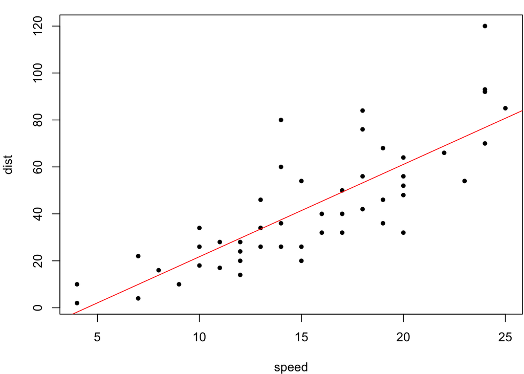

```r
par(mar = c(4, 4, 1, 0.1))
plot(cars, pch = 20)
abline(fit, col = "red")
```

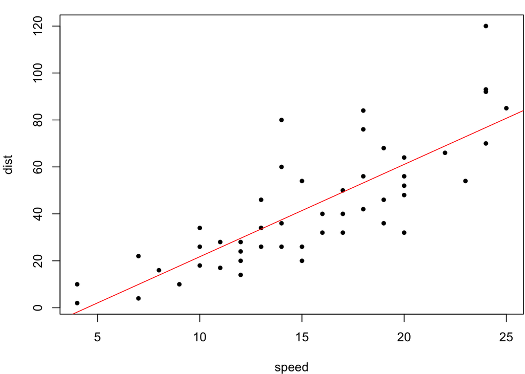

```r
par(mar=c(4, 4, 1, .1))
plot(cars, pch = 20)
abline(fit, col = 'red')
```

A scatterplot with a regression line.

## References

Xie, Yihui. 2015. *Dynamic Documents with R and Knitr*. 2nd ed. Boca Raton, Florida: Chapman; Hall/CRC. http://yihui.name/knitr/.

———. 2016. *Knitr: A General-Purpose Package for Dynamic Report Generation in R*. http://yihui.name/knitr/.

References

Xie, Yihui. 2015. *Dynamic Documents with R and Knitr*. 2nd ed. Boca Raton, Florida: Chapman; Hall/CRC. http://yihui.org/knitr/.

———. 2016. *Knitr: A General-Purpose Package for Dynamic Report Generation in R*. http://yihui.org/knitr/.

[^1]: e.g. the [main manual](https://yihui.name/knitr/demo/manual/) and the [graphics manual](https://yihui.name/knitr/demo/graphics/)

[^1]: e.g. the [main manual](https://yihui.org/knitr/demo/manual/) and the [graphics manual](https://yihui.org/knitr/demo/graphics/)